# Big Data in R

05.06.2020

## Inhalt

- Was ist Big Data?
- Big Data in R
- ff Paket
- Anime Daten
- Vorgehen
- Code

## Was ist Big Data?

“Big data” is high-volume, -velocity and -variety information assets that demand cost-effective, innovative forms of information processing for enhanced insight and decision making.

https://www.gartner.com/en/information-technology/glossary/big-data https://www.sas.com/de_ch/insights/big-data/what-is-big-data.html

## Big Data in R

- Data > RAM
- Dataset > 2 GB wird schwierig
- int64 Datentyp gibt es nicht
  - (2^31 -1) –> max. 2’147’483’647 Indexierung möglich
- Daumenregel: RAM 2-3x > Datasetgrösse

## Big Data in R

- Probleme
  - RAM/OS Limitierung
  - Lange Bearbeitungszeit
- Lösung
  - Mehr RAM / Teilen & herrschen
  - Parallelität

## Big Data in R

- (<2 GB)
  - Lade bestimmte Spalten/Zeilen
- (2-10 GB)
  - bigmemory, ff
- (10 GB >)
  - hadoop, Spark, ..
  - https://rstudio.com/resources/webinars/working-with-big-data-in-r/

## Big Data in R > 10GB mit dplyr

[figure not shown]

1. Connects: Verbindung zur Datenbank (z.B RJDBC)
2. Transform: R in SQL
3. Run: SQL ins DBMS (Datawarehouse) schicken und ausführen
4. Collect: Ergebnis in R (lazy execution)

## ff Paket

- hilft beim Überwinden des RAM-Problems
- Universität Göttingen
- Daten werden aufgeteilt

http://citeseerx.ist.psu.edu/viewdoc/download?doi=10.1.1.487.1317&rep=rep1&type=pdf

## Anime Daten

- Daten über Zuschauer von Anime
- 9GB gross

## Vorgehen

1. ff Package testen
2. Problemgrösse verkleinern (5000 zeiliger Sample)
3. Statistische Modelle vorbereiten
4. Modelle auf Bigdata Datensatz anwenden

## ff Vorbereitung

```r
# RAM grösse
memory.limit()
```

```
## [1] 8089
```

```r
## ff Vorbereiten
sourcePath <- "D:/Users/sugeelan/RProject_Anime/myanimelist/UserAnimeList.csv"
tempPath <- "D:/Users/sugeelan/RProject_Anime/TEMP"
outZIP <- "D:/Users/sugeelan/RProject_Anime/Out1"

## Check Temp path
getOption("fftempdir")
```

```r
tempfile()
```

```
## [1] "C:\\Users\\sugeelan\\AppData\\Local\\Temp\\RtmpkdKGFy\\file1204330c3e5"
```

```r
## set Temp path
#options("fftempdir" = tempPath)
```

## ff Daten speichern

```r
############################################ SAVE DATA in Tempfolder
# anime.ffdf <- read.csv.ffdf(file=sourcePath)

# outPath <- outZIP # D:/Users/sugeelan/RProject_Anime/Out1
# td <- outPath
# tmpFile <- outPath

##### save the ffdf into the supplied directory
# save.ffdf(anime.ffdf, dir=td) # Ausgabeordner (targetdirectory) ohne .zip

##### remove the ffdf from memory
# rm("anime.ffdf")

##### and reload the stored ffdf
# load.ffdf(dir=td)

# tf <- paste(tmpFile, ".zip", sep="")
# packed <- pack.ffdf(file=tf, anime.ffdf) # 30 Min. in Zip verpacken

##### remove the ffdf from memory
# rm("anime.ffdf")
```

## ff Daten laden

```r
######################################## Load Data from Zip file
# restore the ffdf from the packed ffdf
# unter TF ish "D:/Users/sugeelan/RProject_Anime/Out1.zip"
# tf <- "D:/Users/sugeelan/RProject_Anime/Out1.zip"
# unpack.ffdf(tf)
```

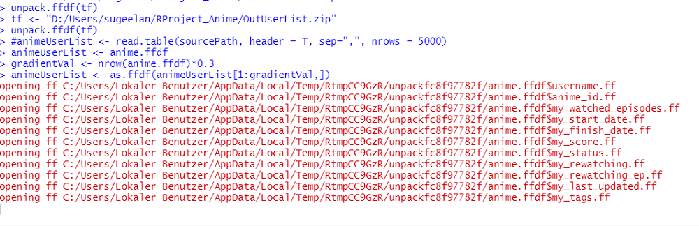

## run

- 30 % der Daten verarbeiten

## Plot 2

```r
####
library(RColorBrewer)

#View(anime)

animeID_member <- anime$anime_id[anime$members == max(anime$members)][1] #max(anime$members) 730076
animeID_rank <- as.integer(table(anime$anime_id[anime$rank == 1]))[1]
animeID_popularity <- anime$anime_id[anime$popularity == 10][1]

db <- merge(db, anime[c("anime_id", "title")], by = "anime_id")



#db$anime_id == animeID_member

#db$anime_id == animeID_member

#tmp <- db[db$anime_id == animeID_member[1], ]



serie_trimmed <- db[which(db$anime_id == animeID_member |
                            db$anime_id == animeID_rank |
                            db$anime_id == animeID_popularity),]
#serie_trimmed$gender.f <- factor(db$gender, labels = c("Uknown", "Female", "Male"))
serie_trimmed$gender.f <- serie_trimmed$gender


p12 <- ggplot(serie_trimmed, aes(x = title, y = birth_date_age, fill = gender.f)) +
  geom_boxplot(alpha = 0.7) +
  scale_y_continuous(name = "Altersverteilung",
                     breaks = seq(18, 36, 6),
                     limits = c(18, 36)) +
  scale_x_discrete(name = "Anime ID") +
  ggtitle("Boxplots für Animes") +
  theme_bw() +
  theme(plot.title = element_text(size = 14, family = "Tahoma", face = "bold"),
        text = element_text(size = 12, family = "Tahoma"),
        axis.title = element_text(face = "bold"),
        axis.text.x = element_text(size = 11)) +
  scale_fill_brewer(palette = "Accent")
p12
```

[output not shown]

## Probleme

[figure not shown]

- RAM / Speicher > Tempfolder wird nicht gewechselt
- 5000 Zeilen laden
- ffdf.data.frame
- data.frame.ffdf
- Rtools -> ZIP Probleme

## Probleme

- Kaeggle Notepad: 12 GB RAM, 4 GB Disk
- Colab Notepad: 12 GB RAM, 120 GB Disk
- R-Studio Cloud: 1 GB RAM, 1 CPU